# Using the data collected from existing customers, build a model that will help the marketing team identify potential customers who are relatively more likely to subscribe term deposit and thus increas

### Deliverable 2: Prepare Data for Analytics: Create Training and Test Sets

###### Create Different train_test_split for each of the data matrices

```python
from sklearn.model_selection import train_test_split

X1_train, X1_test, y_train, y_test = train_test_split(X1, y, test_size=0.3, random_state=3)
X1_train.head()
```

|  | age | default | balance | housing | loan | day | duration | campaign | pdays | previous | ... | month_jul | month_jun | month_mar | month_may | month_nov | month_oct | month_sep | poutcome_other | poutcome_success | poutcome_unknown |
| --- | --- | --- | --- | --- | --- | --- | --- | --- | --- | --- | --- | --- | --- | --- | --- | --- | --- | --- | --- | --- | --- |
| 24103 | 58 | 0 | 372 | 0 | 1 | 29 | 11 | 1 | -1 | 0 | ... | 0 | 0 | 0 | 0 | 0 | 1 | 0 | 0 | 0 | 1 |
| 34104 | 26 | 0 | 2503 | 0 | 0 | 30 | 121 | 1 | 63 | 2 | ... | 0 | 0 | 0 | 0 | 0 | 0 | 0 | 0 | 0 | 0 |
| 14387 | 57 | 0 | 808 | 0 | 0 | 14 | 417 | 3 | -1 | 0 | ... | 1 | 0 | 0 | 0 | 0 | 0 | 0 | 0 | 0 | 1 |
| 13641 | 53 | 0 | -139 | 0 | 0 | 9 | 328 | 3 | -1 | 0 | ... | 1 | 0 | 0 | 0 | 0 | 0 | 0 | 0 | 0 | 1 |
| 37104 | 55 | 0 | 2171 | 1 | 1 | 13 | 318 | 5 | 176 | 1 | ... | 0 | 0 | 0 | 1 | 0 | 0 | 0 | 0 | 1 | 0 |

5 rows × 42 columns

```python
X2_train, X2_test, y_train, y_test = train_test_split(X2, y, test_size=0.3, random_state=3)
X2_train.head()
```

|  | age | default | balance | housing | loan | day | duration | campaign | pdays | previous | ... | month_jul | month_jun | month_mar | month_may | month_nov | month_oct | month_sep | poutcome_other | poutcome_success | poutcome_unknown |
| --- | --- | --- | --- | --- | --- | --- | --- | --- | --- | --- | --- | --- | --- | --- | --- | --- | --- | --- | --- | --- | --- |
| 24103 | 58 | 0 | 372 | 0 | 1 | 29 | 11 | 1 | 40.197828 | 0 | ... | 0 | 0 | 0 | 0 | 0 | 1 | 0 | 0 | 0 | 1 |
| 34104 | 26 | 0 | 2503 | 0 | 0 | 30 | 121 | 1 | 63.000000 | 2 | ... | 0 | 0 | 0 | 0 | 0 | 0 | 0 | 0 | 0 | 0 |
| 14387 | 57 | 0 | 808 | 0 | 0 | 14 | 417 | 3 | 40.197828 | 0 | ... | 1 | 0 | 0 | 0 | 0 | 0 | 0 | 0 | 0 | 1 |
| 13641 | 53 | 0 | -139 | 0 | 0 | 9 | 328 | 3 | 40.197828 | 0 | ... | 1 | 0 | 0 | 0 | 0 | 0 | 0 | 0 | 0 | 1 |
| 37104 | 55 | 0 | 2171 | 1 | 1 | 13 | 318 | 5 | 176.000000 | 1 | ... | 0 | 0 | 0 | 1 | 0 | 0 | 0 | 0 | 1 | 0 |

5 rows × 42 columns

```python
X3_train, X3_test, y_train, y_test = train_test_split(X3, y, test_size=0.3, random_state=3)
X3_train.head()
```

|  | default | balance | housing | loan | day | duration | campaign | pdays | job_blue-collar | job_entrepreneur | ... | month_jul | month_jun | month_mar | month_may | month_nov | month_oct | month_sep | poutcome_other | poutcome_success | poutcome_unknown |
| --- | --- | --- | --- | --- | --- | --- | --- | --- | --- | --- | --- | --- | --- | --- | --- | --- | --- | --- | --- | --- | --- |
| 24103 | 0 | 372 | 0 | 1 | 29 | 11 | 1 | 40.197828 | 0 | 0 | ... | 0 | 0 | 0 | 0 | 0 | 1 | 0 | 0 | 0 | 1 |
| 34104 | 0 | 2503 | 0 | 0 | 30 | 121 | 1 | 63.000000 | 0 | 0 | ... | 0 | 0 | 0 | 0 | 0 | 0 | 0 | 0 | 0 | 0 |
| 14387 | 0 | 808 | 0 | 0 | 14 | 417 | 3 | 40.197828 | 0 | 0 | ... | 1 | 0 | 0 | 0 | 0 | 0 | 0 | 0 | 0 | 1 |
| 13641 | 0 | -139 | 0 | 0 | 9 | 328 | 3 | 40.197828 | 0 | 0 | ... | 1 | 0 | 0 | 0 | 0 | 0 | 0 | 0 | 0 | 1 |
| 37104 | 0 | 2171 | 1 | 1 | 13 | 318 | 5 | 176.000000 | 0 | 0 | ... | 0 | 0 | 0 | 1 | 0 | 0 | 0 | 0 | 1 | 0 |

5 rows × 40 columns

### Deliverable 3: Create Ensembe Model: Logistic Regression

###### Logistic regression Creation - matrix X1

```python
import statsmodels.api as sm

logit=sm.Logit(y_train, sm.add_constant(X1_train))
logit_fit=logit.fit()
logit_fit.summary()
```

```
Optimization terminated successfully.
         Current function value: 0.240736
         Iterations 8
```

Logit Regression Results

| Dep. Variable: | Target | No. Observations: | 31647 |
| --- | --- | --- | --- |
| Model: | Logit | Df Residuals: | 31604 |
| Method: | MLE | Df Model: | 42 |
| Date: | Fri, 11 Dec 2020 | Pseudo R-squ.: | 0.3319 |
| Time: | 21:22:51 | Log-Likelihood: | -7618.6 |
| converged: | True | LL-Null: | -11404. |
| Covariance Type: | nonrobust | LLR p-value: | 0.000 |

|  | coef | std err | z | P>\|z\| | [0.025 | 0.975] |
| --- | --- | --- | --- | --- | --- | --- |
| const | -2.4775 | 0.219 | -11.312 | 0.000 | -2.907 | -2.048 |
| age | -0.0016 | 0.003 | -0.592 | 0.554 | -0.007 | 0.004 |
| default | 0.0834 | 0.189 | 0.441 | 0.659 | -0.287 | 0.454 |
| balance | 1.228e-05 | 6.1e-06 | 2.013 | 0.044 | 3.21e-07 | 2.42e-05 |
| housing | -0.6367 | 0.052 | -12.203 | 0.000 | -0.739 | -0.534 |
| loan | -0.4266 | 0.071 | -5.985 | 0.000 | -0.566 | -0.287 |
| day | 0.0117 | 0.003 | 3.929 | 0.000 | 0.006 | 0.018 |
| duration | 0.0042 | 7.68e-05 | 54.198 | 0.000 | 0.004 | 0.004 |
| campaign | -0.0828 | 0.012 | -7.084 | 0.000 | -0.106 | -0.060 |
| pdays | 3.456e-05 | 0.000 | 0.094 | 0.925 | -0.001 | 0.001 |
| previous | 0.0095 | 0.007 | 1.418 | 0.156 | -0.004 | 0.023 |
| job_blue-collar | -0.3458 | 0.086 | -4.029 | 0.000 | -0.514 | -0.178 |
| job_entrepreneur | -0.3947 | 0.147 | -2.683 | 0.007 | -0.683 | -0.106 |
| job_housemaid | -0.5765 | 0.165 | -3.485 | 0.000 | -0.901 | -0.252 |
| job_management | -0.1642 | 0.087 | -1.888 | 0.059 | -0.335 | 0.006 |
| job_retired | 0.2109 | 0.116 | 1.813 | 0.070 | -0.017 | 0.439 |
| job_self-employed | -0.4302 | 0.138 | -3.115 | 0.002 | -0.701 | -0.160 |
| job_services | -0.2772 | 0.101 | -2.757 | 0.006 | -0.474 | -0.080 |
| job_student | 0.3523 | 0.131 | 2.685 | 0.007 | 0.095 | 0.609 |
| job_technician | -0.1512 | 0.082 | -1.850 | 0.064 | -0.311 | 0.009 |
| job_unemployed | -0.2896 | 0.134 | -2.160 | 0.031 | -0.552 | -0.027 |
| job_unknown | -0.2342 | 0.277 | -0.846 | 0.398 | -0.777 | 0.309 |
| marital_married | -0.1935 | 0.070 | -2.785 | 0.005 | -0.330 | -0.057 |
| marital_single | 0.0707 | 0.080 | 0.889 | 0.374 | -0.085 | 0.227 |
| education_secondary | 0.0818 | 0.076 | 1.073 | 0.283 | -0.068 | 0.231 |
| education_tertiary | 0.2727 | 0.089 | 3.071 | 0.002 | 0.099 | 0.447 |
| education_unknown | 0.2750 | 0.123 | 2.243 | 0.025 | 0.035 | 0.515 |
| contact_telephone | -0.2364 | 0.091 | -2.598 | 0.009 | -0.415 | -0.058 |
| contact_unknown | -1.6698 | 0.086 | -19.305 | 0.000 | -1.839 | -1.500 |
| month_aug | -0.7373 | 0.094 | -7.848 | 0.000 | -0.921 | -0.553 |
| month_dec | 0.5761 | 0.216 | 2.662 | 0.008 | 0.152 | 1.000 |
| month_feb | -0.1739 | 0.107 | -1.620 | 0.105 | -0.384 | 0.036 |
| month_jan | -1.1941 | 0.144 | -8.288 | 0.000 | -1.476 | -0.912 |
| month_jul | -0.8636 | 0.093 | -9.337 | 0.000 | -1.045 | -0.682 |
| month_jun | 0.5192 | 0.111 | 4.679 | 0.000 | 0.302 | 0.737 |
| month_mar | 1.4882 | 0.141 | 10.571 | 0.000 | 1.212 | 1.764 |
| month_may | -0.3705 | 0.086 | -4.305 | 0.000 | -0.539 | -0.202 |
| month_nov | -0.8190 | 0.099 | -8.241 | 0.000 | -1.014 | -0.624 |
| month_oct | 0.9415 | 0.129 | 7.286 | 0.000 | 0.688 | 1.195 |
| month_sep | 0.7038 | 0.142 | 4.955 | 0.000 | 0.425 | 0.982 |
| poutcome_other | 0.2379 | 0.108 | 2.206 | 0.027 | 0.027 | 0.449 |
| poutcome_success | 2.3128 | 0.099 | 23.425 | 0.000 | 2.119 | 2.506 |
| poutcome_unknown | 0.0159 | 0.111 | 0.143 | 0.887 | -0.203 | 0.234 |

```python
from sklearn.metrics import confusion_matrix, recall_score, precision_score, f1_score, roc_auc_score,accuracy_score
from sklearn.linear_model import LogisticRegression

logreg = LogisticRegression(max_iter=1000,random_state=3)
logreg.fit(X1_train, y_train)
```

```
LogisticRegression(max_iter=1000, random_state=3)
```

```python
y_predict = logreg.predict(X1_test)
y_predict # Predicting the target variable on test data
```

```
array([0, 0, 0, ..., 0, 0, 0], dtype=int64)
```

```python
y_pred_prob = logreg.predict_proba(X1_test)
y_pred_prob[:,1]
```

```
array([0.02096006, 0.0417399 , 0.02944515, ..., 0.01019343, 0.03701382,
       0.10631507])
```

###### Logistic regression Confusion Matrix - matrix X1

```python
def draw_cm( actual, predicted ):
    cm = confusion_matrix( actual, predicted)
    sns.heatmap(cm, annot=True,  fmt='.0f', xticklabels = [0,1] , yticklabels = [0,1] )
    plt.ylabel('Observed')
    plt.xlabel('Predicted')
    plt.show()
```

```
First Logit Model Confusion Matrix Output
```

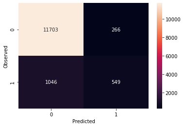

```python
print('First Logit Model Confusion Matrix Output')
draw_cm(y_test,y_predict)
print()
```

###### Logistic regression Model Results - matrix X1

```python
TP = 549
FP = 266
FN = 1046
TN = 11703
Recall = TP/(TP+FN)
Precision = TP/(TP+FP)
print('Recall [TP/(TP+FN)] for Logit_model_1 = {0:.2f}'.format(Recall))
print('Precision [TP/(TP+FP)] for Logit_model_1 = {0:.2f}'.format(Precision))
print('F1 Score [2.Precision.Recall / (Precision + Recall)] for Logit_model_1 = {0:.2f}'.format((2*Recall*Precision)/(Recall+Precision)))
print('Accuracy [(TP+TN)/(TP+TN+FP+FN)] for Logit_model_1 = {0:.2f}'.format((TP+TN)/(TP+TN+FP+FN)))
```

```
Recall [TP/(TP+FN)] for Logit_model_1 = 0.34
Precision [TP/(TP+FP)] for Logit_model_1 = 0.67
F1 Score [2.Precision.Recall / (Precision + Recall)] for Logit_model_1 = 0.46
Accuracy [(TP+TN)/(TP+TN+FP+FN)] for Logit_model_1 = 0.90
```

###### Logistic regression Creation - matrix X2

```python
logit=sm.Logit(y_train, sm.add_constant(X2_train))
logit_fit=logit.fit()
logit_fit.summary()
```

```
Optimization terminated successfully.
         Current function value: 0.236164
         Iterations 8
```

Logit Regression Results

| Dep. Variable: | Target | No. Observations: | 31647 |
| --- | --- | --- | --- |
| Model: | Logit | Df Residuals: | 31604 |
| Method: | MLE | Df Model: | 42 |
| Date: | Fri, 11 Dec 2020 | Pseudo R-squ.: | 0.3446 |
| Time: | 21:22:57 | Log-Likelihood: | -7473.9 |
| converged: | True | LL-Null: | -11404. |
| Covariance Type: | nonrobust | LLR p-value: | 0.000 |

|  | coef | std err | z | P>\|z\| | [0.025 | 0.975] |
| --- | --- | --- | --- | --- | --- | --- |
| const | -2.1642 | 0.231 | -9.351 | 0.000 | -2.618 | -1.711 |
| age | -0.0014 | 0.003 | -0.513 | 0.608 | -0.007 | 0.004 |
| default | 0.0970 | 0.191 | 0.507 | 0.612 | -0.278 | 0.472 |
| balance | 1.19e-05 | 6.17e-06 | 1.928 | 0.054 | -1.98e-07 | 2.4e-05 |
| housing | -0.6349 | 0.053 | -12.048 | 0.000 | -0.738 | -0.532 |
| loan | -0.4281 | 0.072 | -5.957 | 0.000 | -0.569 | -0.287 |
| day | 0.0119 | 0.003 | 3.955 | 0.000 | 0.006 | 0.018 |
| duration | 0.0044 | 7.81e-05 | 56.693 | 0.000 | 0.004 | 0.005 |
| campaign | -0.0835 | 0.012 | -7.071 | 0.000 | -0.107 | -0.060 |
| pdays | -0.0019 | 0.001 | -3.433 | 0.001 | -0.003 | -0.001 |
| previous | 0.0092 | 0.007 | 1.406 | 0.160 | -0.004 | 0.022 |
| job_blue-collar | -0.3593 | 0.087 | -4.145 | 0.000 | -0.529 | -0.189 |
| job_entrepreneur | -0.4090 | 0.149 | -2.747 | 0.006 | -0.701 | -0.117 |
| job_housemaid | -0.6020 | 0.167 | -3.604 | 0.000 | -0.929 | -0.275 |
| job_management | -0.1730 | 0.088 | -1.971 | 0.049 | -0.345 | -0.001 |
| job_retired | 0.1923 | 0.118 | 1.636 | 0.102 | -0.038 | 0.423 |
| job_self-employed | -0.4416 | 0.139 | -3.172 | 0.002 | -0.714 | -0.169 |
| job_services | -0.2782 | 0.101 | -2.744 | 0.006 | -0.477 | -0.079 |
| job_student | 0.3523 | 0.132 | 2.665 | 0.008 | 0.093 | 0.611 |
| job_technician | -0.1585 | 0.082 | -1.921 | 0.055 | -0.320 | 0.003 |
| job_unemployed | -0.3054 | 0.135 | -2.259 | 0.024 | -0.570 | -0.040 |
| job_unknown | -0.2500 | 0.280 | -0.892 | 0.373 | -0.799 | 0.300 |
| marital_married | -0.1997 | 0.070 | -2.845 | 0.004 | -0.337 | -0.062 |
| marital_single | 0.0707 | 0.080 | 0.880 | 0.379 | -0.087 | 0.228 |
| education_secondary | 0.0801 | 0.077 | 1.042 | 0.297 | -0.071 | 0.231 |
| education_tertiary | 0.2669 | 0.090 | 2.976 | 0.003 | 0.091 | 0.443 |
| education_unknown | 0.2776 | 0.124 | 2.243 | 0.025 | 0.035 | 0.520 |
| contact_telephone | -0.2263 | 0.092 | -2.466 | 0.014 | -0.406 | -0.046 |
| contact_unknown | -1.6989 | 0.087 | -19.568 | 0.000 | -1.869 | -1.529 |
| month_aug | -0.7535 | 0.095 | -7.924 | 0.000 | -0.940 | -0.567 |
| month_dec | 0.5932 | 0.217 | 2.739 | 0.006 | 0.169 | 1.018 |
| month_feb | -0.1794 | 0.108 | -1.653 | 0.098 | -0.392 | 0.033 |
| month_jan | -1.2181 | 0.145 | -8.384 | 0.000 | -1.503 | -0.933 |
| month_jul | -0.8986 | 0.094 | -9.589 | 0.000 | -1.082 | -0.715 |
| month_jun | 0.5114 | 0.112 | 4.568 | 0.000 | 0.292 | 0.731 |
| month_mar | 1.5066 | 0.142 | 10.629 | 0.000 | 1.229 | 1.784 |
| month_may | -0.3683 | 0.087 | -4.225 | 0.000 | -0.539 | -0.197 |
| month_nov | -0.8678 | 0.101 | -8.617 | 0.000 | -1.065 | -0.670 |
| month_oct | 0.9344 | 0.130 | 7.160 | 0.000 | 0.679 | 1.190 |
| month_sep | 0.6877 | 0.143 | 4.794 | 0.000 | 0.407 | 0.969 |
| poutcome_other | 0.2163 | 0.109 | 1.978 | 0.048 | 0.002 | 0.431 |
| poutcome_success | 2.2436 | 0.099 | 22.713 | 0.000 | 2.050 | 2.437 |
| poutcome_unknown | -0.3000 | 0.112 | -2.678 | 0.007 | -0.520 | -0.080 |

```python
logreg = LogisticRegression(max_iter=1000,random_state=3)
logreg.fit(X2_train, y_train)
```

```
LogisticRegression(max_iter=1000, random_state=3)
```

```python
y_predict = logreg.predict(X2_test)
y_predict # Predicting the target variable on test data
```

```
array([0, 0, 0, ..., 0, 0, 0], dtype=int64)
```

```python
y_pred_prob = logreg.predict_proba(X2_test)
y_pred_prob[:,1]
```

```
array([0.01565173, 0.03159406, 0.02638624, ..., 0.01053885, 0.04275443,
       0.09988315])
```

###### Logistic regression Confusion Matrix - matrix X2

```python
def draw_cm( actual, predicted ):
    cm = confusion_matrix( actual, predicted)
    sns.heatmap(cm, annot=True,  fmt='.0f', xticklabels = [0,1] , yticklabels = [0,1] )
    plt.ylabel('Observed')
    plt.xlabel('Predicted')
    plt.show()
```

```
First Logit Model Confusion Matrix Output
```

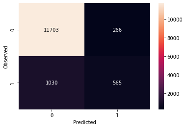

```python
print('First Logit Model Confusion Matrix Output')
draw_cm(y_test,y_predict)
print()
```

###### Logistic regression Model Results - matrix X2

```python
TP = 565
FP = 266
FN = 1030
TN = 11703
Recall = TP/(TP+FN)
Precision = TP/(TP+FP)
print('Recall [TP/(TP+FN)] for Logit_model_1 = {0:.2f}'.format(Recall))
print('Precision [TP/(TP+FP)] for Logit_model_1 = {0:.2f}'.format(Precision))
print('F1 Score [2.Precision.Recall / (Precision + Recall)] for Logit_model_1 = {0:.2f}'.format((2*Recall*Precision)/(Recall+Precision)))
print('Accuracy [(TP+TN)/(TP+TN+FP+FN)] for Logit_model_1 = {0:.2f}'.format((TP+TN)/(TP+TN+FP+FN)))
```

```
Recall [TP/(TP+FN)] for Logit_model_1 = 0.35
Precision [TP/(TP+FP)] for Logit_model_1 = 0.68
F1 Score [2.Precision.Recall / (Precision + Recall)] for Logit_model_1 = 0.47
Accuracy [(TP+TN)/(TP+TN+FP+FN)] for Logit_model_1 = 0.90
```

###### Logistic regression Creation - matrix X3

```python
logit=sm.Logit(y_train, sm.add_constant(X3_train))
logit_fit=logit.fit()
logit_fit.summary()
```

```
Optimization terminated successfully.
         Current function value: 0.236199
         Iterations 8
```

Logit Regression Results

| Dep. Variable: | Target | No. Observations: | 31647 |
| --- | --- | --- | --- |
| Model: | Logit | Df Residuals: | 31606 |
| Method: | MLE | Df Model: | 40 |
| Date: | Fri, 11 Dec 2020 | Pseudo R-squ.: | 0.3445 |
| Time: | 21:23:04 | Log-Likelihood: | -7475.0 |
| converged: | True | LL-Null: | -11404. |
| Covariance Type: | nonrobust | LLR p-value: | 0.000 |

|  | coef | std err | z | P>\|z\| | [0.025 | 0.975] |
| --- | --- | --- | --- | --- | --- | --- |
| const | -2.2004 | 0.193 | -11.407 | 0.000 | -2.578 | -1.822 |
| default | 0.0975 | 0.191 | 0.509 | 0.611 | -0.278 | 0.473 |
| balance | 1.166e-05 | 6.16e-06 | 1.892 | 0.058 | -4.19e-07 | 2.37e-05 |
| housing | -0.6303 | 0.052 | -12.040 | 0.000 | -0.733 | -0.528 |
| loan | -0.4269 | 0.072 | -5.943 | 0.000 | -0.568 | -0.286 |
| day | 0.0118 | 0.003 | 3.930 | 0.000 | 0.006 | 0.018 |
| duration | 0.0044 | 7.81e-05 | 56.691 | 0.000 | 0.004 | 0.005 |
| campaign | -0.0830 | 0.012 | -7.043 | 0.000 | -0.106 | -0.060 |
| pdays | -0.0019 | 0.001 | -3.463 | 0.001 | -0.003 | -0.001 |
| job_blue-collar | -0.3596 | 0.087 | -4.152 | 0.000 | -0.529 | -0.190 |
| job_entrepreneur | -0.4132 | 0.149 | -2.776 | 0.005 | -0.705 | -0.122 |
| job_housemaid | -0.6114 | 0.167 | -3.670 | 0.000 | -0.938 | -0.285 |
| job_management | -0.1740 | 0.088 | -1.983 | 0.047 | -0.346 | -0.002 |
| job_retired | 0.1647 | 0.106 | 1.559 | 0.119 | -0.042 | 0.372 |
| job_self-employed | -0.4428 | 0.139 | -3.181 | 0.001 | -0.716 | -0.170 |
| job_services | -0.2780 | 0.101 | -2.744 | 0.006 | -0.477 | -0.079 |
| job_student | 0.3645 | 0.130 | 2.810 | 0.005 | 0.110 | 0.619 |
| job_technician | -0.1587 | 0.082 | -1.925 | 0.054 | -0.320 | 0.003 |
| job_unemployed | -0.3087 | 0.135 | -2.284 | 0.022 | -0.574 | -0.044 |
| job_unknown | -0.2554 | 0.280 | -0.912 | 0.362 | -0.805 | 0.294 |
| marital_married | -0.1955 | 0.070 | -2.798 | 0.005 | -0.332 | -0.059 |
| marital_single | 0.0854 | 0.075 | 1.133 | 0.257 | -0.062 | 0.233 |
| education_secondary | 0.0835 | 0.077 | 1.091 | 0.275 | -0.066 | 0.233 |
| education_tertiary | 0.2724 | 0.089 | 3.063 | 0.002 | 0.098 | 0.447 |
| education_unknown | 0.2763 | 0.124 | 2.233 | 0.026 | 0.034 | 0.519 |
| contact_telephone | -0.2312 | 0.091 | -2.541 | 0.011 | -0.410 | -0.053 |
| contact_unknown | -1.7000 | 0.087 | -19.590 | 0.000 | -1.870 | -1.530 |
| month_aug | -0.7535 | 0.095 | -7.927 | 0.000 | -0.940 | -0.567 |
| month_dec | 0.5960 | 0.216 | 2.753 | 0.006 | 0.172 | 1.020 |
| month_feb | -0.1769 | 0.108 | -1.631 | 0.103 | -0.389 | 0.036 |
| month_jan | -1.2155 | 0.145 | -8.365 | 0.000 | -1.500 | -0.931 |
| month_jul | -0.8965 | 0.094 | -9.568 | 0.000 | -1.080 | -0.713 |
| month_jun | 0.5129 | 0.112 | 4.581 | 0.000 | 0.293 | 0.732 |
| month_mar | 1.5073 | 0.142 | 10.636 | 0.000 | 1.230 | 1.785 |
| month_may | -0.3668 | 0.087 | -4.209 | 0.000 | -0.538 | -0.196 |
| month_nov | -0.8686 | 0.101 | -8.628 | 0.000 | -1.066 | -0.671 |
| month_oct | 0.9352 | 0.130 | 7.173 | 0.000 | 0.680 | 1.191 |
| month_sep | 0.6882 | 0.143 | 4.799 | 0.000 | 0.407 | 0.969 |
| poutcome_other | 0.2275 | 0.109 | 2.087 | 0.037 | 0.014 | 0.441 |
| poutcome_success | 2.2426 | 0.099 | 22.709 | 0.000 | 2.049 | 2.436 |
| poutcome_unknown | -0.3290 | 0.110 | -2.989 | 0.003 | -0.545 | -0.113 |

```python
logreg = LogisticRegression(max_iter=1000,random_state=3)
logreg.fit(X3_train, y_train)
```

```
LogisticRegression(max_iter=1000, random_state=3)
```

```python
y_predict = logreg.predict(X3_test)
y_predict # Predicting the target variable on test data
```

```
array([0, 0, 0, ..., 0, 0, 0], dtype=int64)
```

```python
y_pred_prob = logreg.predict_proba(X3_test)
y_pred_prob[:,1]
```

```
array([0.01491637, 0.02766975, 0.02181775, ..., 0.00758575, 0.04055925,
       0.1280374 ])
```

###### Logistic regression Confusion Matrix - matrix X3

```python
def draw_cm( actual, predicted ):
    cm = confusion_matrix( actual, predicted)
    sns.heatmap(cm, annot=True,  fmt='.0f', xticklabels = [0,1] , yticklabels = [0,1] )
    plt.ylabel('Observed')
    plt.xlabel('Predicted')
    plt.show()
```

```
First Logit Model Confusion Matrix Output
```

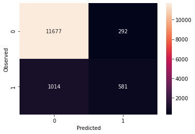

```python
print('First Logit Model Confusion Matrix Output')
draw_cm(y_test,y_predict)
print()
```

###### Logistic regression Model Results - matrix X3

```python
from sklearn.metrics import classification_report

# Create report for final evaluation of models at the end
report1 = classification_report(y_test, y_predict, output_dict=True)
```

```python
TP = 581
FP = 292
FN = 1014
TN = 11677
Recall = TP/(TP+FN)
Precision = TP/(TP+FP)
print('Recall [TP/(TP+FN)] for Logit_model_1 = {0:.2f}'.format(Recall))
print('Precision [TP/(TP+FP)] for Logit_model_1 = {0:.2f}'.format(Precision))
print('F1 Score [2.Precision.Recall / (Precision + Recall)] for Logit_model_1 = {0:.2f}'.format((2*Recall*Precision)/(Recall+Precision)))
print('Accuracy [(TP+TN)/(TP+TN+FP+FN)] for Logit_model_1 = {0:.2f}'.format((TP+TN)/(TP+TN+FP+FN)))
```

```
Recall [TP/(TP+FN)] for Logit_model_1 = 0.36
Precision [TP/(TP+FP)] for Logit_model_1 = 0.67
F1 Score [2.Precision.Recall / (Precision + Recall)] for Logit_model_1 = 0.47
Accuracy [(TP+TN)/(TP+TN+FP+FN)] for Logit_model_1 = 0.90
```

###### Logistic regression performance using different matrices

- Recall & Precision improved from matrix X1 to X2, where we replace both duration & pdays outliers with the "maximum" duration & pdays respectively, as well as replace pdays -1 with mean of pdays
- Recall improved from matrix X1 to X3, where we drop age, as its pairplot with other variable with a hue=Target shows no obvious relationship, also drop previous because its IQR is 0

### Deliverable 3: Create Ensembe Model: Decision Tree

###### Decision Tree Creation - matrix X1

```python
from sklearn.tree import DecisionTreeClassifier # to build a classification tree
from sklearn.tree import plot_tree # to draw a classification tree
from sklearn.model_selection import cross_val_score # for cross validation
from sklearn.metrics import plot_confusion_matrix # to draw a confusion matrix
```

```python
# Create a decision tree and fit it to the training data
dt_clf = DecisionTreeClassifier(random_state=3,min_samples_leaf=5,splitter='best',max_leaf_nodes=190)
dt_clf = dt_clf.fit(X1_train, y_train)
```

```python
from sklearn import tree

train_char_label = ['No', 'Yes']
Complex_Tree_File = open('complex_tree.dot','w')
dot_data = tree.export_graphviz(dt_clf, out_file=Complex_Tree_File, feature_names = X1.columns, class_names = list(train_char_label))
Complex_Tree_File.close()
```

```python
from os import system
from IPython.display import Image

#Works only if "dot" command works on your machine

retCode = system("dot -Tpng complex_tree.dot -o complex_tree.png")
if(retCode>0):
    print("system command returning error: "+str(retCode))
else:
    display(Image("complex_tree.png"))
```

[figure not shown]

```
<sklearn.metrics._plot.confusion_matrix.ConfusionMatrixDisplay at 0x2f4b7702760>
```

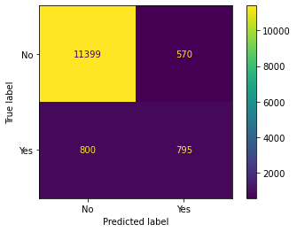

```python
# Plot_confusion_matrix
plot_confusion_matrix(dt_clf, X1_test, y_test, display_labels=["No", "Yes"])
```

```python
y_predict3 = dt_clf.predict(X1_test)
y_predict3 # Predicting the target variable on test data
```

```
array([0, 0, 0, ..., 0, 0, 0], dtype=int64)
```

```python
# Create report for final evaluation of models at the end
report3 = classification_report(y_test, y_predict3, output_dict=True)
```

###### Decision Tree Model Results - matrix X1

```python
TP = 795
FP = 570
FN = 800
TN = 11399
Recall = TP/(TP+FN)
Precision = TP/(TP+FP)
print('Recall [TP/(TP+FN)] for Decision_tree = {0:.2f}'.format(Recall))
print('Precision [TP/(TP+FP)] for Decision_tree = {0:.2f}'.format(Precision))
print('F1 Score [2.Precision.Recall / (Precision + Recall)] for Decision_tree = {0:.2f}'.format((2*Recall*Precision)/(Recall+Precision)))
print('Accuracy [(TP+TN)/(TP+TN+FP+FN)] for Decision_tree = {0:.2f}'.format((TP+TN)/(TP+TN+FP+FN)))
```

```
Recall [TP/(TP+FN)] for Decision_tree = 0.50
Precision [TP/(TP+FP)] for Decision_tree = 0.58
F1 Score [2.Precision.Recall / (Precision + Recall)] for Decision_tree = 0.54
Accuracy [(TP+TN)/(TP+TN+FP+FN)] for Decision_tree = 0.90
```

###### Decision Tree Creation - matrix X2

```python
# Fit it to the training data
dt_clf = dt_clf.fit(X2_train, y_train)
```

```
<sklearn.metrics._plot.confusion_matrix.ConfusionMatrixDisplay at 0x2f4b7fc76d0>
```

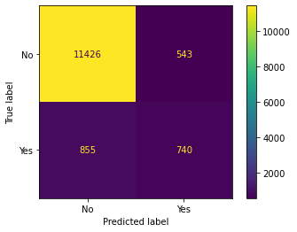

```python
# Plot_confusion_matrix
plot_confusion_matrix(dt_clf, X2_test, y_test, display_labels=["No", "Yes"])
```

```python
y_predict3 = dt_clf.predict(X2_test)
y_predict3 # Predicting the target variable on test data
```

```
array([0, 0, 0, ..., 0, 0, 0], dtype=int64)
```

###### Decision Tree Model Results - matrix X2

```python
TP = 740
FP = 543
FN = 855
TN = 11426
Recall = TP/(TP+FN)
Precision = TP/(TP+FP)
print('Recall [TP/(TP+FN)] for Decision_tree = {0:.2f}'.format(Recall))
print('Precision [TP/(TP+FP)] for Decision_tree = {0:.2f}'.format(Precision))
print('F1 Score [2.Precision.Recall / (Precision + Recall)] for Decision_tree = {0:.2f}'.format((2*Recall*Precision)/(Recall+Precision)))
print('Accuracy [(TP+TN)/(TP+TN+FP+FN)] for Decision_tree = {0:.2f}'.format((TP+TN)/(TP+TN+FP+FN)))
```

```
Recall [TP/(TP+FN)] for Decision_tree = 0.46
Precision [TP/(TP+FP)] for Decision_tree = 0.58
F1 Score [2.Precision.Recall / (Precision + Recall)] for Decision_tree = 0.51
Accuracy [(TP+TN)/(TP+TN+FP+FN)] for Decision_tree = 0.90
```

###### Decision Tree Creation - matrix X3

```python
# Fit it to the training data
dt_clf = dt_clf.fit(X3_train, y_train)
```

```
<sklearn.metrics._plot.confusion_matrix.ConfusionMatrixDisplay at 0x2f4bd092a30>
```

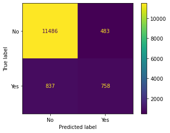

```python
# Plot_confusion_matrix
plot_confusion_matrix(dt_clf, X3_test, y_test, display_labels=["No", "Yes"])
```

```python
y_predict3 = dt_clf.predict(X3_test)
y_predict3 # Predicting the target variable on test data
```

```
array([0, 0, 0, ..., 0, 0, 0], dtype=int64)
```

###### Decision Tree Model Results - matrix X3

```python
TP = 758
FP = 483
FN = 837
TN = 11486
Recall = TP/(TP+FN)
Precision = TP/(TP+FP)
print('Recall [TP/(TP+FN)] for Decision_tree = {0:.2f}'.format(Recall))
print('Precision [TP/(TP+FP)] for Decision_tree = {0:.2f}'.format(Precision))
print('F1 Score [2.Precision.Recall / (Precision + Recall)] for Decision_tree = {0:.2f}'.format((2*Recall*Precision)/(Recall+Precision)))
print('Accuracy [(TP+TN)/(TP+TN+FP+FN)] for Decision_tree = {0:.2f}'.format((TP+TN)/(TP+TN+FP+FN)))
```

```
Recall [TP/(TP+FN)] for Decision_tree = 0.48
Precision [TP/(TP+FP)] for Decision_tree = 0.61
F1 Score [2.Precision.Recall / (Precision + Recall)] for Decision_tree = 0.53
Accuracy [(TP+TN)/(TP+TN+FP+FN)] for Decision_tree = 0.90
```

###### Decision Tree performance using different matrices

- Recall reduced from matrix X1 to X2, where we replace both duration & pdays outliers with the "maximum" duration & pdays respectively, as well as replace pdays -1 with mean of pdays
- Recall improved from matrix X2 to X3, where we drop age, as its pairplot with other variable with a hue=Target shows no obvious relationship, also drop previous because its IQR is 0
- Precision improved from matrix X2 to X3, where we drop age, as its pairplot with other variable with a hue=Target shows no obvious relationship, also drop previous because its IQR is 0

### Deliverable 3: Create Ensemble Model: Build Ensemble Models (Bagging and Boosting)

###### Bagging Ensemble Model - matrix X1

```python
from sklearn.ensemble import BaggingClassifier
from sklearn import metrics

bgcl = BaggingClassifier(n_estimators=100,random_state=3)

bgcl = bgcl.fit(X1_train, y_train)
```

```
0.9048953111176644
```

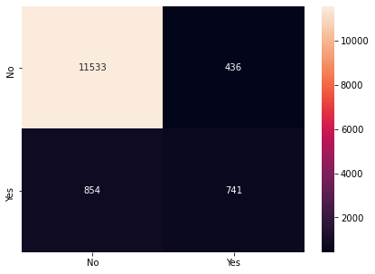

```python
y_predict4 = bgcl.predict(X1_test)

print(bgcl.score(X1_test , y_test))

cm4=metrics.confusion_matrix(y_test, y_predict4, labels=[0, 1])

df_cm4 = pd.DataFrame(cm4, index = [i for i in ["No","Yes"]],
                  columns = [i for i in ["No","Yes"]])
plt.figure(figsize = (7,5))
sns.heatmap(df_cm4, annot=True ,fmt='g')
```

###### Bagging Ensemble Model Results - matrix X1

```python
TP = 741
FP = 436
FN = 854
TN = 11533
Recall = TP/(TP+FN)
Precision = TP/(TP+FP)
print('Recall [TP/(TP+FN)] for Bagging_Ensemble = {0:.2f}'.format(Recall))
print('Precision [TP/(TP+FP)] for Bagging_Ensemble = {0:.2f}'.format(Precision))
print('F1 Score [2.Precision.Recall / (Precision + Recall)] for Bagging_Ensemble = {0:.2f}'.format((2*Recall*Precision)/(Recall+Precision)))
print('Accuracy [(TP+TN)/(TP+TN+FP+FN)] for Bagging_Ensemble = {0:.2f}'.format((TP+TN)/(TP+TN+FP+FN)))
```

```
Recall [TP/(TP+FN)] for Bagging_Ensemble = 0.46
Precision [TP/(TP+FP)] for Bagging_Ensemble = 0.63
F1 Score [2.Precision.Recall / (Precision + Recall)] for Bagging_Ensemble = 0.53
Accuracy [(TP+TN)/(TP+TN+FP+FN)] for Bagging_Ensemble = 0.90
```

###### Bagging Ensemble Model - matrix X2

```python
bgcl = bgcl.fit(X2_train, y_train)
```

```
0.9051164848127397
```

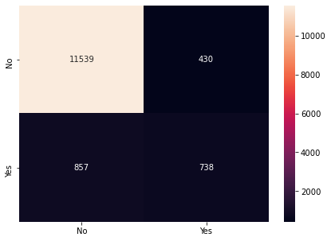

```python
y_predict4 = bgcl.predict(X2_test)

print(bgcl.score(X2_test , y_test))

cm4=metrics.confusion_matrix(y_test, y_predict4, labels=[0, 1])

df_cm4 = pd.DataFrame(cm4, index = [i for i in ["No","Yes"]],
                  columns = [i for i in ["No","Yes"]])
plt.figure(figsize = (7,5))
sns.heatmap(df_cm4, annot=True ,fmt='g')
```

```python
# Create report for final evaluation of models at the end
report4 = classification_report(y_test, y_predict4, output_dict=True)
```

###### Bagging Ensemble Model Results - matrix X2

```python
TP = 738
FP = 430
FN = 857
TN = 11539
Recall = TP/(TP+FN)
Precision = TP/(TP+FP)
print('Recall [TP/(TP+FN)] for Bagging_Ensemble = {0:.2f}'.format(Recall))
print('Precision [TP/(TP+FP)] for Bagging_Ensemble = {0:.2f}'.format(Precision))
print('F1 Score [2.Precision.Recall / (Precision + Recall)] for Bagging_Ensemble = {0:.2f}'.format((2*Recall*Precision)/(Recall+Precision)))
print('Accuracy [(TP+TN)/(TP+TN+FP+FN)] for Bagging_Ensemble = {0:.2f}'.format((TP+TN)/(TP+TN+FP+FN)))
```

```
Recall [TP/(TP+FN)] for Bagging_Ensemble = 0.46
Precision [TP/(TP+FP)] for Bagging_Ensemble = 0.63
F1 Score [2.Precision.Recall / (Precision + Recall)] for Bagging_Ensemble = 0.53
Accuracy [(TP+TN)/(TP+TN+FP+FN)] for Bagging_Ensemble = 0.91
```

###### Bagging Ensemble Model - matrix X3

```python
bgcl = bgcl.fit(X3_train, y_train)
```

```
0.9048215865526393
```

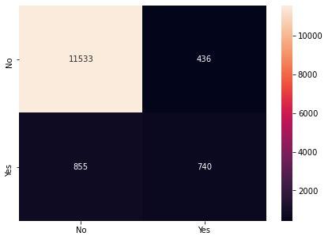

```python
y_predict4 = bgcl.predict(X3_test)

print(bgcl.score(X3_test , y_test))

cm4=metrics.confusion_matrix(y_test, y_predict4, labels=[0, 1])

df_cm4 = pd.DataFrame(cm4, index = [i for i in ["No","Yes"]],
                  columns = [i for i in ["No","Yes"]])
plt.figure(figsize = (7,5))
sns.heatmap(df_cm4, annot=True ,fmt='g')
```

###### Bagging Ensemble Model Results - matrix X3

```python
TP = 740
FP = 436
FN = 855
TN = 11533
Recall = TP/(TP+FN)
Precision = TP/(TP+FP)
print('Recall [TP/(TP+FN)] for Bagging_Ensemble = {0:.2f}'.format(Recall))
print('Precision [TP/(TP+FP)] for Bagging_Ensemble = {0:.2f}'.format(Precision))
print('F1 Score [2.Precision.Recall / (Precision + Recall)] for Bagging_Ensemble = {0:.2f}'.format((2*Recall*Precision)/(Recall+Precision)))
print('Accuracy [(TP+TN)/(TP+TN+FP+FN)] for Bagging_Ensemble = {0:.2f}'.format((TP+TN)/(TP+TN+FP+FN)))
```

```
Recall [TP/(TP+FN)] for Bagging_Ensemble = 0.46
Precision [TP/(TP+FP)] for Bagging_Ensemble = 0.63
F1 Score [2.Precision.Recall / (Precision + Recall)] for Bagging_Ensemble = 0.53
Accuracy [(TP+TN)/(TP+TN+FP+FN)] for Bagging_Ensemble = 0.90
```

###### Bagging performance using different matrices

- Accuracy improved from matrix X1 to X2, where we replace both duration & pdays outliers with the "maximum" duration & pdays respectively, as well as replace pdays -1 with mean of pdays

###### Random Forest Ensemble Model - matrix X1

```python
from sklearn.ensemble import RandomForestClassifier

rfcl = RandomForestClassifier(n_estimators = 100, random_state=3,max_features=15, min_samples_leaf=3)
rfcl = rfcl.fit(X1_train, y_train)
```

```
0.9093187850191684
```

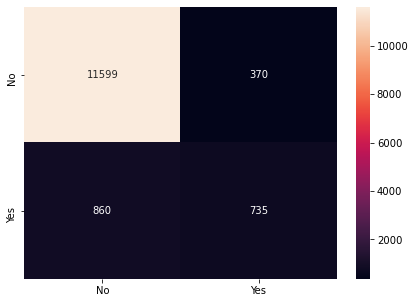

```python
y_predict5 = rfcl.predict(X1_test)
print(rfcl.score(X1_test, y_test))
cm5=metrics.confusion_matrix(y_test, y_predict5, labels=[0, 1])

df_cm5 = pd.DataFrame(cm5, index = [i for i in ["No","Yes"]],
                  columns = [i for i in ["No","Yes"]])
plt.figure(figsize = (7,5))
sns.heatmap(df_cm5, annot=True ,fmt='g')
```

```python
# Create report for final evaluation of models at the end
report5 = classification_report(y_test, y_predict5, output_dict=True)
```